# Data Wrangling in R - Data Wrangling - 2

One should look for what is and not what he thinks should be. (Albert Einstein)

# Module completion checklist

| Objective | Complete |
| --- | --- |
| Demonstrate installing a package and loading a library |  |
| Define the six functions that provide verbs for the language of data manipulation, from the package dplyr |  |

# Packages and datasets in R

- We’ve now spent some time wrangling the CMP dataset by:
  - creating a subset of the data
  - identifying missing values (NAs)
  - imputing a new value (the mean) to replace missing values
- To continue practicing data wrangling, we are going install a series of packages intended to help with data wrangling tasks, known as the `tidyverse`
- We will also prepare to use some datasets available directly within R as packages

# Packages in RStudio

- R packages are an extension of the R programming language
- They are collections of compiled code, sample data, and documentation
- They are typically installed from the CRAN (the Comprehensive R Archive Network)
- Learn more about ‘base’ and ‘add-on’ packages in R [here](https://cran.r-project.org/doc/FAQ/R-FAQ.html#R-Add_002dOn-Packages)
- The package we’ll be using for the remainder of the course is called the `tidyverse`

[figure not shown]

# Installing packages: package explorer

- RStudio has a built-in package manager in the bottom right pane to help us install packages
- Click on **`Packages`** tab in the bottom-right pane
- Click **`Install`** button next to `Update`
- Type package name in the box and install

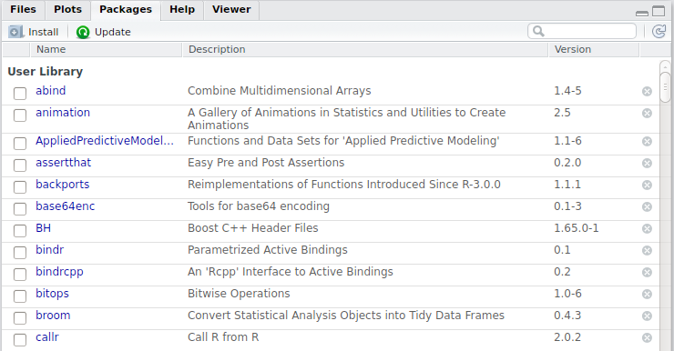

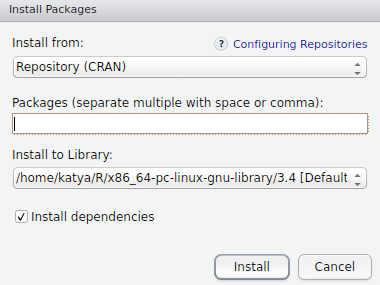

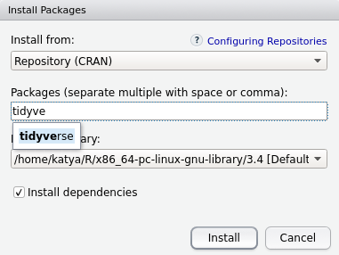

# Installing packages: package explorer

- The installed package should appear in the list of packages in the package explorer

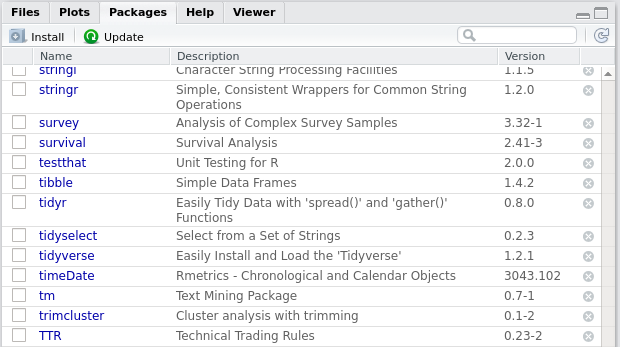

- To load the package into R’s environment, check the box next to the name of your desired package

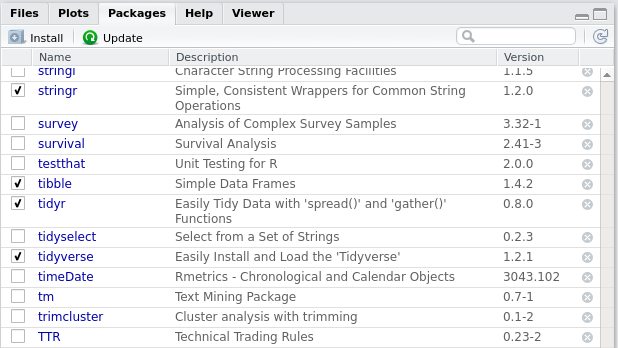

# Installing packages

- If the function we would like to use comes from a `package`, we need to install the `package` first
- In addition to installing `packages` with package explorer as we introduced earlier, we can also use the function `install.packages()`
- For this function, we need to provide a single required argument: a character string corresponding to the `package name`

```r
# Install package
?install.packages
```

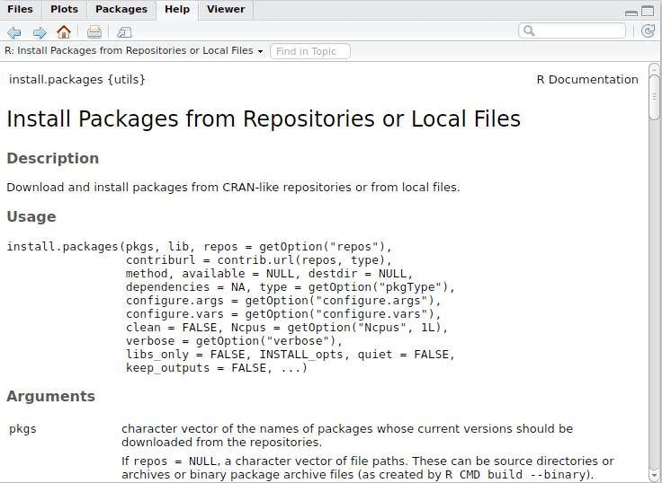

# Installing packages example

- Here is an example of how we install packages with function **`install.packages()`**
- You can always check the detailed documentation of a package with `help = "package name"`

```r
install.packages("tidyverse")   #<- Install package
```

[figure not shown]

# Loading packages in RStudio

- Once installed, it is important that your desired package is properly loaded in R.
- You can do this two different ways:
- The first option uses the `library()` command

```r
library(tidyverse)
library(help = "tidyverse")     #<- View package documentation.
```

- The second option involves locating the package name in the **Packages** pane and checking the appropriate box

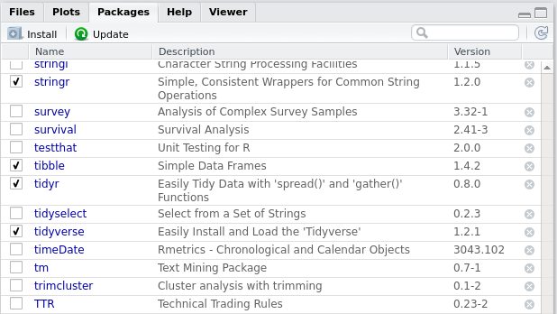

# Detaching packages in RStudio

- Some packages are very large and consume quite a bit of available memory when loaded
- You may want to use `detach()` after usage to free up your computer’s memory

```r
detach(package:tidyverse,unload=TRUE)
```

- You can also uncheck the box by the package’s name on the **Packages** pane
- Note: once detached you can not use any of the packages’ function until reloaded

# Built-in R Datasets

- R comes with several built-in data packages, so that you always have sample data available for exploring how new packages and functions work
  - Titanic: Survival of passengers on the Titanic
  - iris: Edgar Anderson’s Iris Data
  - mtcars: Motor Trend Car Road Tests

# Loading Built-in Datasets

- Loading built-in datasets takes the form of installing a package rather than reading in an external file
- Let’s now install and load the `nycflights13` package

```r
install.packages("nycflights13", repos='http://cran.us.r-project.org')
library(nycflights13)
```

- The `nycflights13` package contains the following five datasets:
  - `flights`: all flights that departed from NYC in 2013
  - `weather`: hourly meteorological data for each airport
  - `planes`: construction information about each plane
  - `airports`: airport names and locations
  - `airlines`: translation between two letter carrier codes and names

# Data transformation with tidyverse

- When you are given messy data, your goal is to transform it into a usable format
- To do this, you may need the help from multiple **packages** that can be found within the universe of [`tidyverse`](https://www.tidyverse.org/)
- Some core packages in `tidyverse` are:
  - `ggplot2`
  - `dplyr`
  - `tidyr`
- In this module, we will introduce few functions in `dplyr` that can be used to manipulate data

[figure not shown]

# A little more about tidyverse

- Packages in the tidyverse change fairly frequently
- You can see if updates are available, and optionally install them, by running the following code

```r
tidyverse_update()
```

- Like we noted previously, there are many libraries within the `tidyverse` package
- **The packages we will focus on help you wrangle and manipulate data quickly and efficiently**

# Data transformation

- **`dplyr`** is an essential library within the tidyverse universe
- It will be the tool we use for transforming our data by filtering, aggregating, and summarizing
- Before starting this lesson, understand that dplyr does overwrite some `base R` packages such as `filter` and `lag`
- Even functions with exactly the same name can be of different usage and syntax when belonging to different packages
- If you have loaded dplyr and want to use the base version of the package, you will have to type in the full name:
  - for example `stats::filter` and `stats::lag`

# Framework of dplyr

- The framework of `dplyr` is as follows:
  - The first argument is the **original dataframe**
  - The next arguments describe **what to do with the original dataframe**, using the six key `dplyr` functions
  - The final result is a **new, transformed dataframe**

# Basics of dplyr

- Here are the six key `dplyr` functions we will discuss for the remainder of the course:

| Function | Use Case | Data Type |
| --- | --- | --- |
| `filter` | Pick observations by their value | All data types |
| `arrange` | Reorder the rows | All data types |
| `select` | Pick variables by their names | All data types |
| `mutate` | Create new variables with functions of existing variables | All data types |
| `summarize` | Collapse many values down to a single summary | All data types |
| `group_by` | Allows the above functions to operate on a dataset group by group | All data types |

# Knowledge check

# Module completion checklist

| Objective | Complete |
| --- | --- |
| Demonstrate installing a package and loading a library | **✔** |
| Define the six functions that provide verbs for the language of data manipulation, from the package dplyr | **✔** |

# Congratulations on completing this module!